# Actividad 2 - Problema 4

Juan José Restrepo Rosero

2024-08-14

# **Problema 3 - Teorema del Límite Central**

El Teorema del Límite Central es uno de los más importantes en la inferencia estadística y habla sobre la convergencia de los estimadores como la proporción muestral a la distribución normal. Algunos autores afirman que esta aproximación es bastante buena a partir del umbral *n>30*.

A continuación se describen los siguientes pasos para su verificación:

1. Realice una simulación en la cual genere una población de n=1000 (Lote), donde el porcentaje de individuos (supongamos plantas) enfermas sea del 50%.

b.Genere una función que permita: - Obtener una muestra aleatoria de la población y - Calcule el estimador de la proporción muestral pˆ para un tamaño de muestra dado n.

3. Repita el escenario anterior (b) n=500 veces y analice los resultados en cuanto al comportamiento de los 500 resultados del estimador pˆ. ¿Qué tan simétricos o sesgados son los resultados obtenidos? y ¿qué se puede observar en cuanto a la variabilidad?. Realice en su informe un comentario sobre los resultados obtenidos.
4. Repita los puntos b y c para tamaños de muestra n=5, 10, 15, 20, 30, 50, 60, 100, 200, 500. Compare los resultados obtenidos para los diferentes tamaños de muestra en cuanto a la normalidad. Utilice pruebas de bondad y ajuste (shapiro wilks :shspiro.test()) y métodos gráficos (gráfico de normalidad: qqnorm()). Comente en su informe los resultados obtenidos
5. Repita toda la simulación (puntos a – d), pero ahora para lotes con 10% de plantas enfermas y de nuevo para lotes con un 90% de plantas enfermas. Concluya sobre los resultados del ejercicio.

## **Resultados**

Se generó una población de n=1000 (Lote), donde el porcentaje de individuos (plantas) enfermas es del 50%.

```r
# a. Se crea la ppoblación de 1000 plantas donde el porcentaje de enfermas es del 50%
# ( 1: enferma, 0: sana)

GenerarPoblacion = function(Total = 1000, Enfer = 0.5, Sanas = 0.5) {

  # Redondeamos a cero cifras decimales
  E = round(Total * Enfer, 0)
  S = round(Total * Sanas, 0)
  Poblacion = c(rep("Enfermo", E), rep("Sana",S))

  print(paste("Lote Generado de tamaño: ", Total, " Enfermos: ",E,"Sanos: ",S))
  return(Poblacion)
}

Lote = GenerarPoblacion(Total = 1000, Enfer = 0.5, Sanas = 0.5)
```

```
## [1] "Lote Generado de tamaño:  1000  Enfermos:  500 Sanos:  500"
```

```r
# b. Obtener una muestra aleatoria de la población y calcular el estimador

set.seed(123)
GenerarMuestra = function(Pob, Tam, Con) {
  if (Tam <= length(Pob)) {
    muestra = sample(x = Pob, size = Tam)

    Pob_muestra = sum(muestra == Con)/Tam
    return(Pob_muestra)
  }
  else
  {
    print("Error: el tamaño de la muestra supera el tamaño de la población")
    return(-1)
  }
}

# Prueba
n = 1200
muestra = GenerarMuestra (Pob= Lote, Tam = n, Con = "Enfermo")
```

```
## [1] "Error: el tamaño de la muestra supera el tamaño de la población"
```

```r
print(paste("Para una muestra de tamaño: ", n,
            "se obtuvo un ^P =", muestra))
```

```
## [1] "Para una muestra de tamaño:  1200 se obtuvo un ^P = -1"
```

```r
n = 300
muestra = GenerarMuestra (Pob = Lote, Tam = n, Con = "Enfermo")
print(paste("Para una muestra de tamaño:", n,
            "un estimador de la proporción =", muestra))
```

```
## [1] "Para una muestra de tamaño: 300 un estimador de la proporción = 0.49"
```

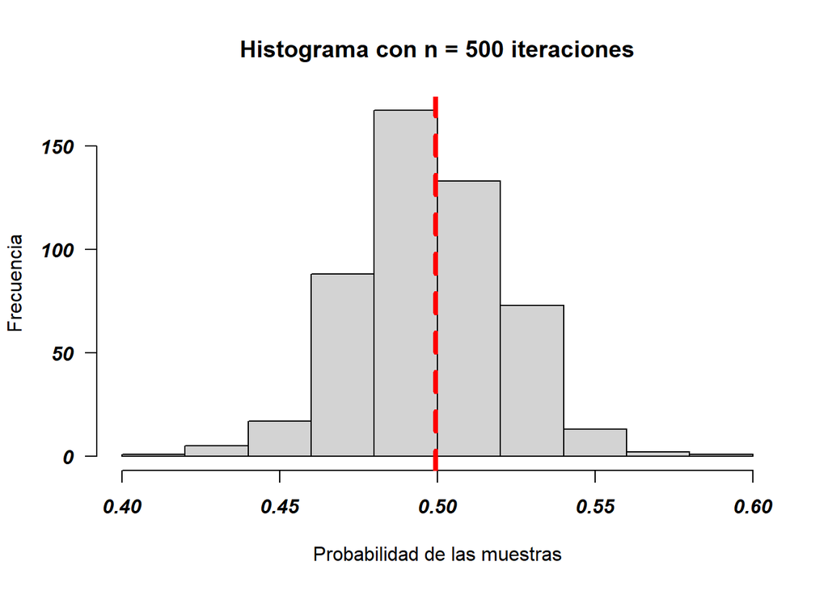

```r
# c. Repita el escenario anterior (b) n = 500 veces y analice los resultados en cuanto al comportamiento de los 500 resultados del estimador pˆ

GenerarMuestra_Iter = function(Pob, Tam, Con, Iter) {
  if (Tam <= length(Pob)) {
    muestra_iter = array(NA, Iter)
    for (i in 1:Iter) {
      muestra_iter[i] = GenerarMuestra(Pob, Tam, Con)
    }
    return(muestra_iter)
  }
  else {
    print("Error: el tamaño de la muestra supera el tamaño de la población.")
    return(-1)
  }
}


iter = 500
P_muestras = GenerarMuestra_Iter(Pob = Lote, Tam = n, Con = "Enfermo", Iter = iter)

hist(P_muestras, main = "Histograma con n = 500 iteraciones",
     xlab = "Probabilidad de las muestras",
     ylab = "Frecuencia",
     las = 1,
     font.axis = 4)

line = mean(P_muestras)

abline (v=line, lwd = 4, lty = 2, col="red")
```

```r
library(moments)

min <- min(P_muestras, na.rm = TRUE)
q1 <- quantile(P_muestras, probs = 0.25, na.rm = TRUE)
media <- mean.default(P_muestras, na.rm = TRUE)
mediana <- median.default(P_muestras, na.rm = TRUE)
var <- var(P_muestras, na.rm = TRUE)
desvest <- sd(P_muestras, na.rm = TRUE)
q3 <- quantile(P_muestras, probs = 0.75, na.rm = TRUE)
max <- max(P_muestras, na.rm = TRUE)
s <- skewness(P_muestras)
c <- kurtosis(P_muestras)

descriptStat <- round(as.numeric(c(min, q1, media, mediana,
                                     var, desvest, q3, max, s, c)),4)
nombresCols <- c("Mínimo", "Q1", "Media",  "Mediana", "Varianza",
             "Desviación", "Q3", "Máximo", "Simetría", "Curtosis")
descr2 <- as.data.frame(rbind(nombresCols, descriptStat))
descr2
```

```
##                  V1     V2     V3      V4       V5         V6     V7     V8
## nombresCols  Mínimo     Q1  Media Mediana Varianza Desviación     Q3 Máximo
## descriptStat 0.4167 0.4833 0.4995     0.5    6e-04     0.0238 0.5167 0.5833
##                    V9      V10
## nombresCols  Simetría Curtosis
## descriptStat   0.0509     3.32
```

Se repite el mismo procedimiento para los puntos b y c con tamaños de muestra de *n = 5, 10, 15, 20, 30, 50, 60, 100, 200 y 500*

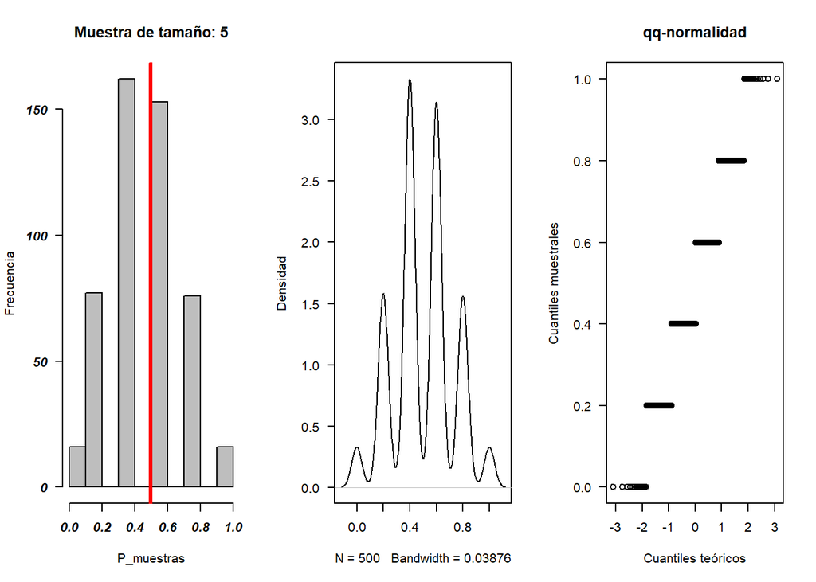

```
## [1] "Para una muestra de tamaño:  5"
##
##  Shapiro-Wilk normality test
##
## data:  P_muestras
## W = 0.9295, p-value = 1.36e-14
```

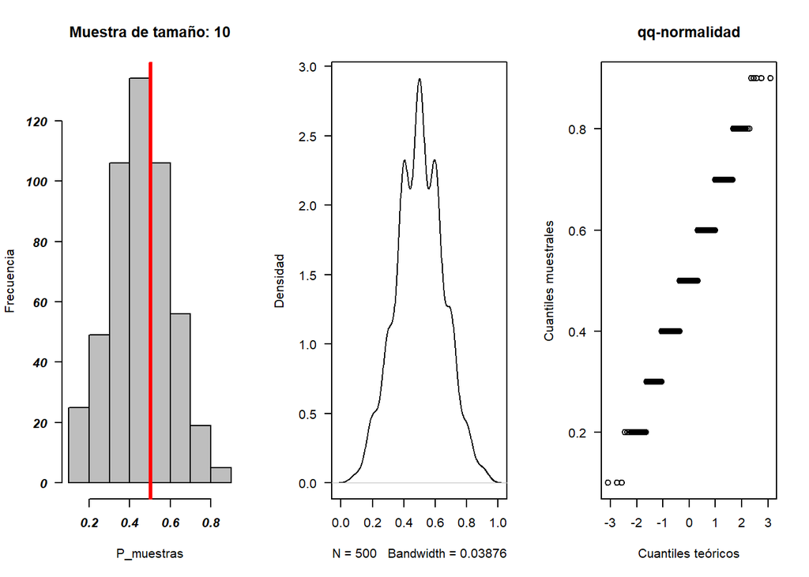

```
## [1] "Para una muestra de tamaño:  10"
##
##  Shapiro-Wilk normality test
##
## data:  P_muestras
## W = 0.96168, p-value = 3.995e-10
```

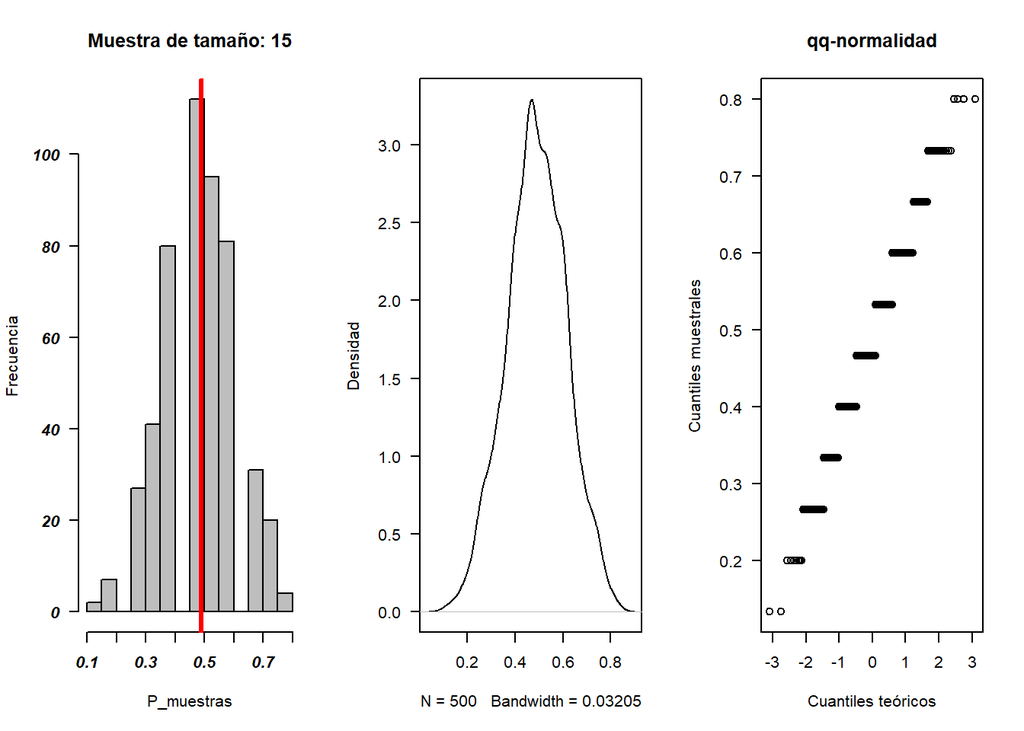

```
## [1] "Para una muestra de tamaño:  15"
##
##  Shapiro-Wilk normality test
##
## data:  P_muestras
## W = 0.97307, p-value = 5.875e-08
```

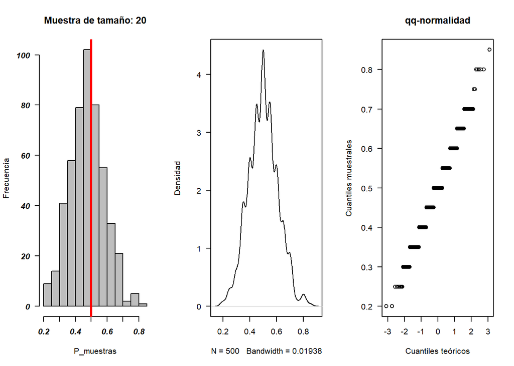

```
## [1] "Para una muestra de tamaño:  20"
##
##  Shapiro-Wilk normality test
##
## data:  P_muestras
## W = 0.98015, p-value = 2.507e-06
```

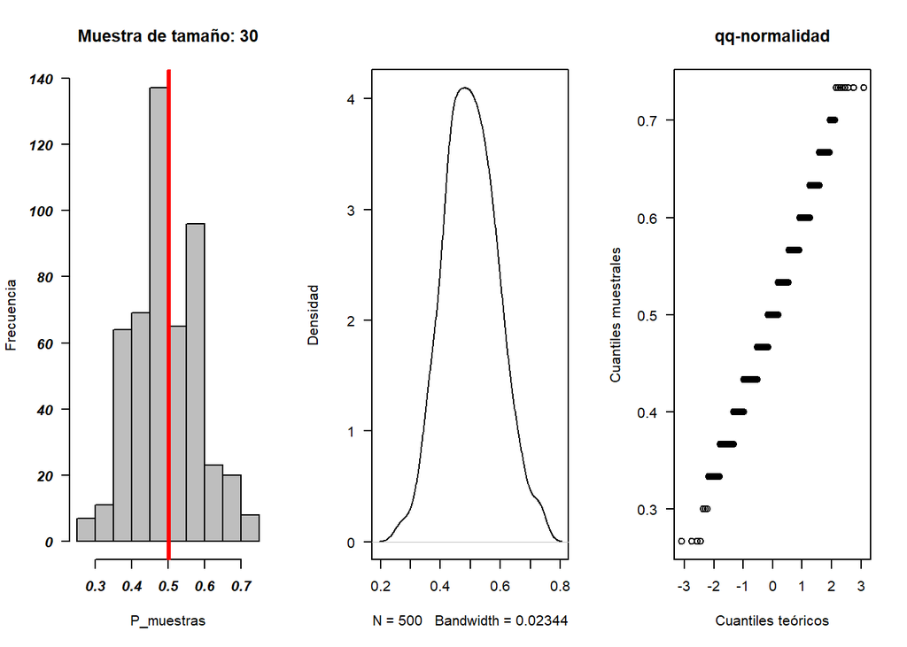

```
## [1] "Para una muestra de tamaño:  30"
##
##  Shapiro-Wilk normality test
##
## data:  P_muestras
## W = 0.98429, p-value = 3.146e-05
```

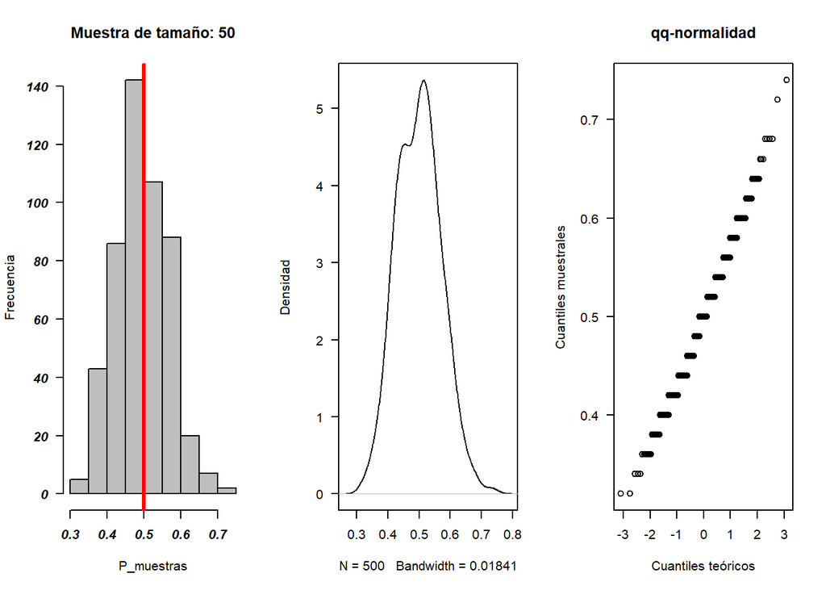

```
## [1] "Para una muestra de tamaño:  50"
##
##  Shapiro-Wilk normality test
##
## data:  P_muestras
## W = 0.98934, p-value = 0.001075
```

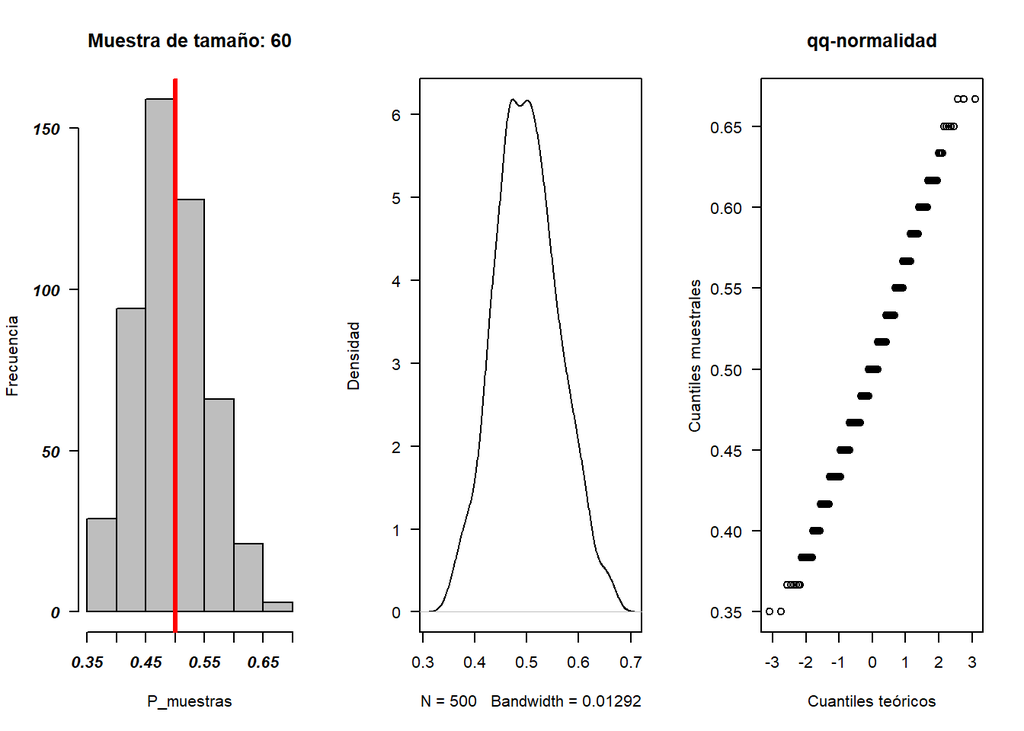

```
## [1] "Para una muestra de tamaño:  60"
##
##  Shapiro-Wilk normality test
##
## data:  P_muestras
## W = 0.98916, p-value = 0.0009348
```

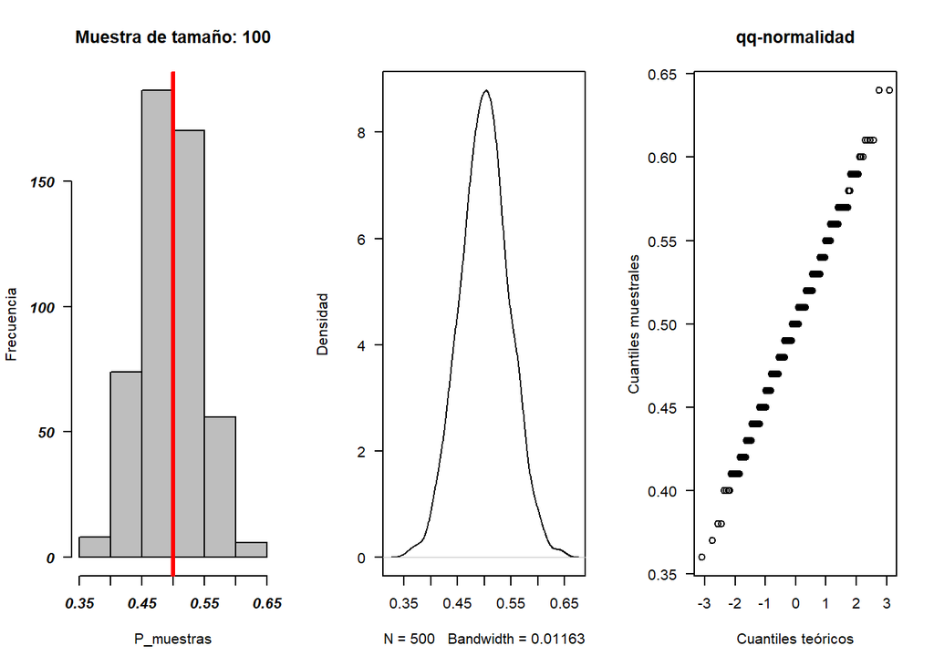

```
## [1] "Para una muestra de tamaño:  100"
##
##  Shapiro-Wilk normality test
##
## data:  P_muestras
## W = 0.99485, p-value = 0.09344
```

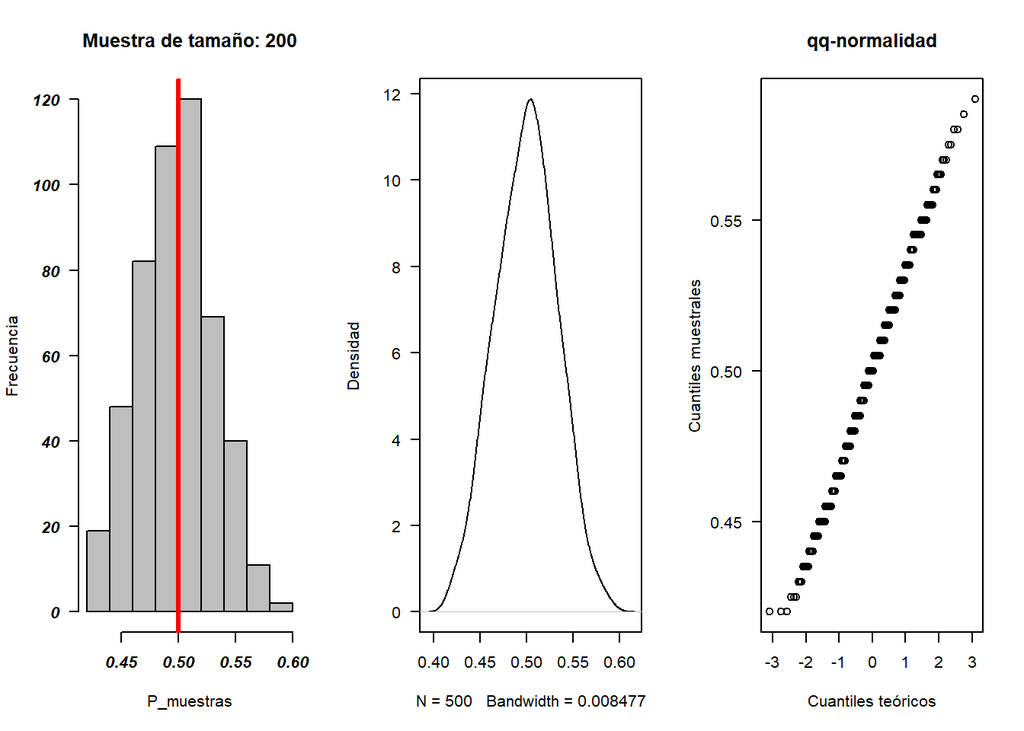

```
## [1] "Para una muestra de tamaño:  200"
##
##  Shapiro-Wilk normality test
##
## data:  P_muestras
## W = 0.995, p-value = 0.1054
```

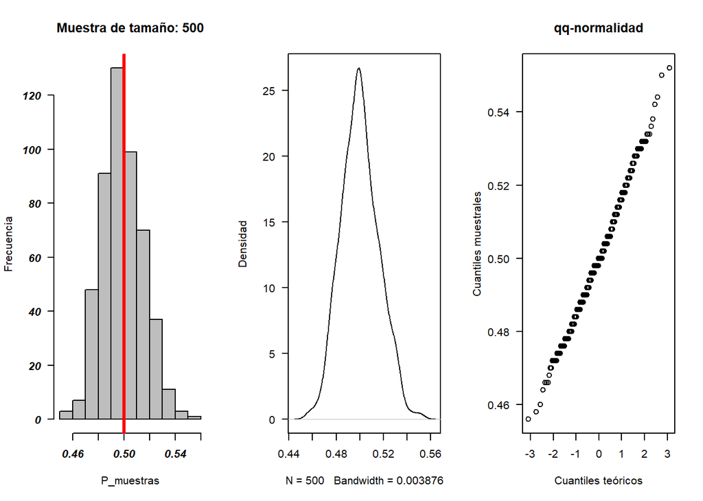

```
## [1] "Para una muestra de tamaño:  500"
##
##  Shapiro-Wilk normality test
##
## data:  P_muestras
## W = 0.99434, p-value = 0.06077
```

```r
library(ggplot2)
library(qqplotr)
t_Muestras = c(5,10,15,20,30,50,60,100,200,500)
iter = 500

for (i in 1:length(t_Muestras)) {
  P_muestras = GenerarMuestra_Iter (Pob = Lote, Tam = t_Muestras[i], Con = "Enfermo",Iter = iter)
  par(mfrow=c(1,3))
  hist(P_muestras, las=1, ylab = "Frecuencia",
       main = paste("Muestra de tamaño:", t_Muestras[i]), col = "gray", las=1,
       font.axis=4)
  abline(v=mean(P_muestras), col = "red", lwd = 3)
  plot(density(P_muestras), las = 1, ylab = "Densidad", main = "")
  qqnorm(P_muestras, xlab = "Cuantiles teóricos", ylab = "Cuantiles muestrales",las = 1, main = "qq-normalidad")
  print(paste('Para una muestra de tamaño: ', t_Muestras[i]))
  print(shapiro.test(P_muestras))

}
```

```r
Lote2 = GenerarPoblacion(Tot = 1000, Enf = 0.1, San = 0.9)
```

```
## [1] "Lote Generado de tamaño:  1000  Enfermos:  100 Sanos:  900"
```

```r
n2 = 300
muestra = GenerarMuestra(Pob = Lote2, Tam = n2, Con = "Enfermo")

print(paste("Para una muestra de tamaño:", n2, "un estimador de la proporción =",muestra))
```

```
## [1] "Para una muestra de tamaño: 300 un estimador de la proporción = 0.0866666666666667"
```

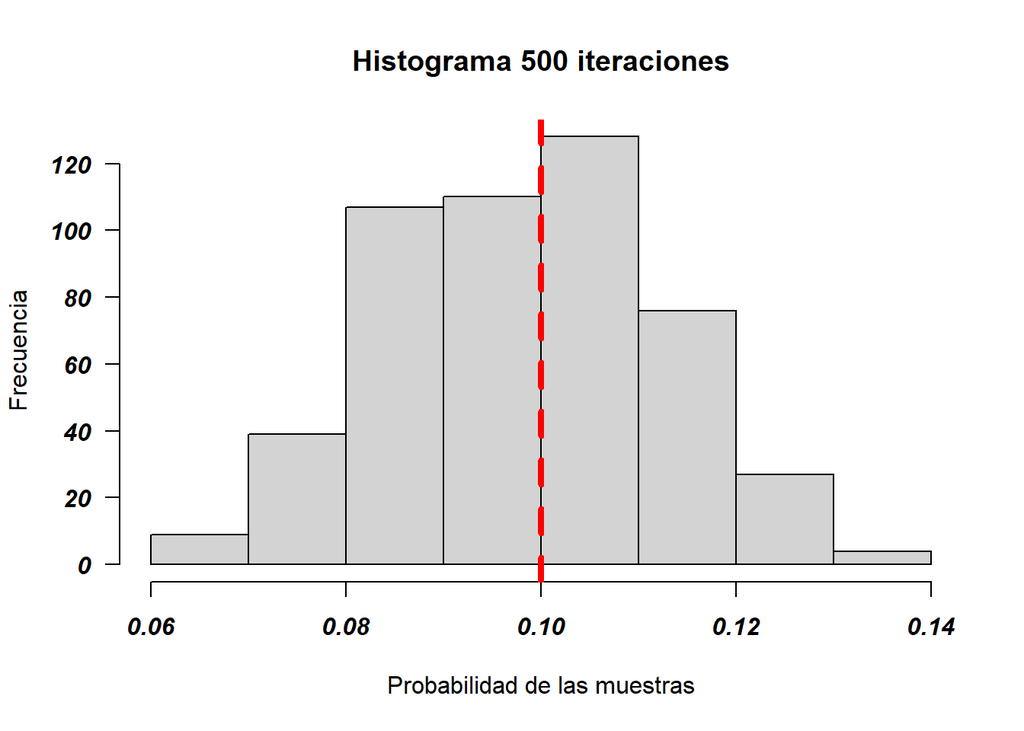

```r
GenerarMuestra_Iter = function(Pob, Tam, Con, Iter) {
  if (Tam <= length(Pob)) {
    muestra_iter = array(NA, Iter)
    for (i in 1:Iter) {
      muestra_iter[i] = GenerarMuestra(Pob, Tam, Con)
    }
    return(muestra_iter)
  }
  else {
    print("Error: el tamaño de la muestra supera el tamaño de la población.")
    return(-1)
  }
}


iter = 500
P_muestras = GenerarMuestra_Iter(Pob = Lote2, Tam = n2, Con = "Enfermo", Iter = iter)

hist(P_muestras, main ="Histograma 500 iteraciones",
     xlab="Probabilidad de las muestras", ylab="Frecuencia", las=1,
     font.axis=4)
line = mean(P_muestras)

abline (v=line, lwd = 4, lty = 2, col="red")
```

```r
library(skimr)
skim(P_muestras)
```

Data summary

| Name | P_muestras |
| --- | --- |
| Number of rows | 500 |
| Number of columns | 1 |
| _______________________ |  |
| Column type frequency: |  |
| numeric | 1 |
| ________________________ |  |
| Group variables | None |

**Variable type: numeric**

| skim_variable | n_missing | complete_rate | mean | sd | p0 | p25 | p50 | p75 | p100 | hist |
| --- | --- | --- | --- | --- | --- | --- | --- | --- | --- | --- |
| data | 0 | 1 | 0.1 | 0.01 | 0.06 | 0.09 | 0.1 | 0.11 | 0.14 | ▂▇▇▆▁ |

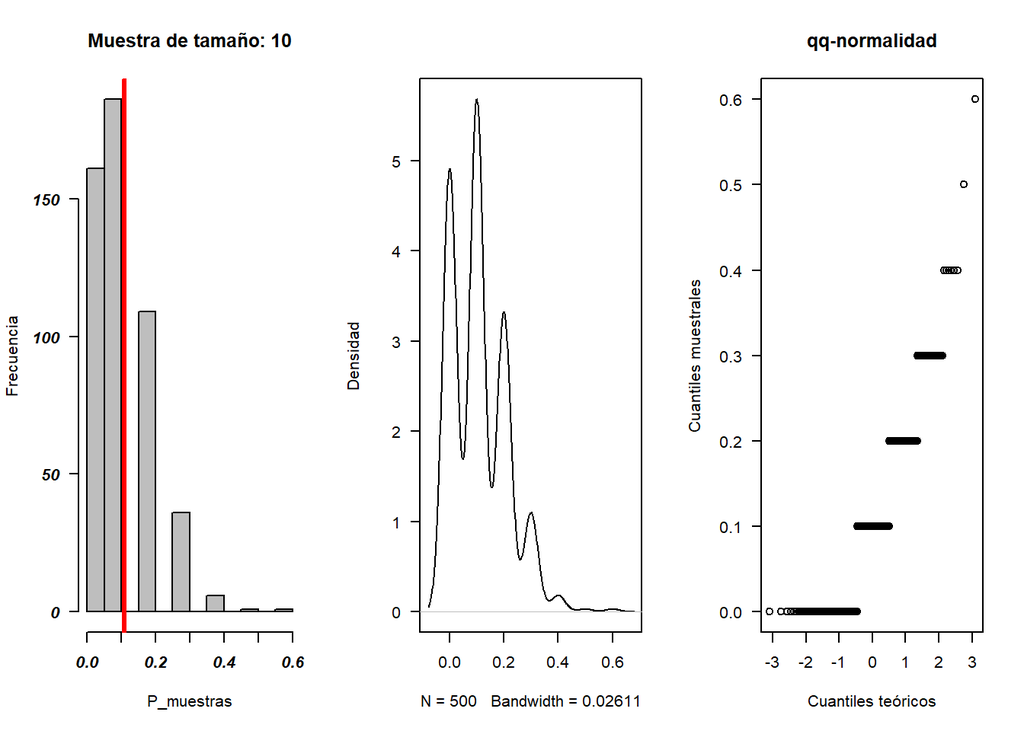

```
## [1] "Para una muestra de tamaño:  10"
##
##  Shapiro-Wilk normality test
##
## data:  P_muestras
## W = 0.85244, p-value < 2.2e-16
```

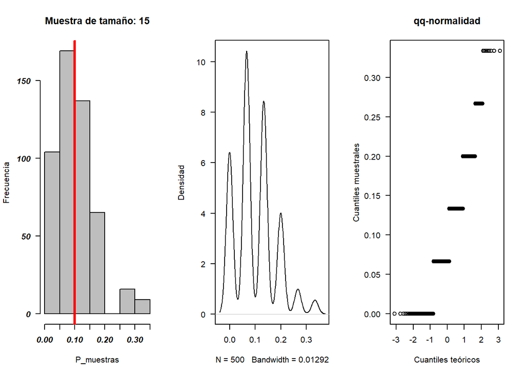

```
## [1] "Para una muestra de tamaño:  15"
##
##  Shapiro-Wilk normality test
##
## data:  P_muestras
## W = 0.89487, p-value < 2.2e-16
```

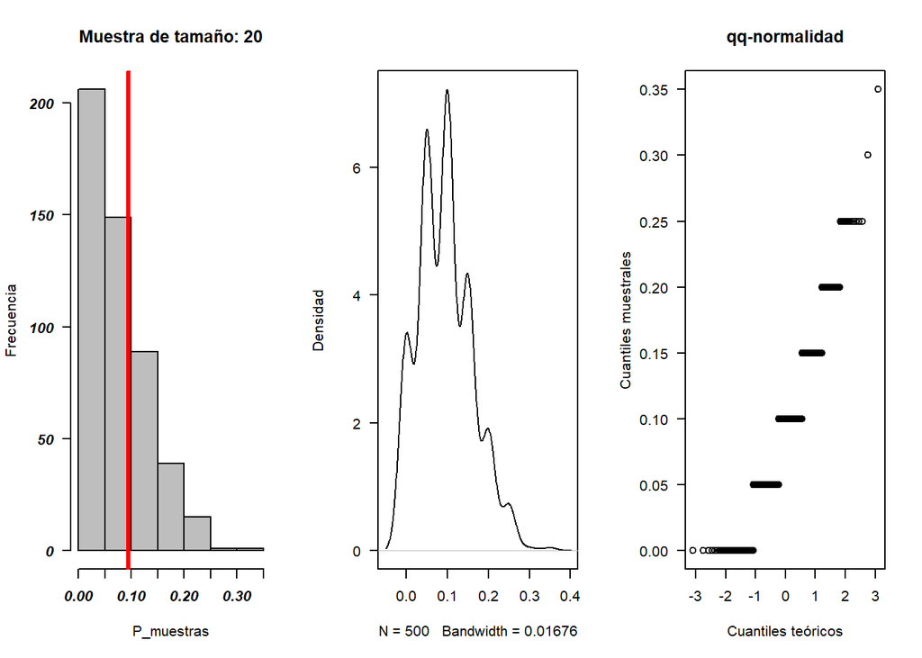

```
## [1] "Para una muestra de tamaño:  20"
##
##  Shapiro-Wilk normality test
##
## data:  P_muestras
## W = 0.92275, p-value = 2.426e-15
```

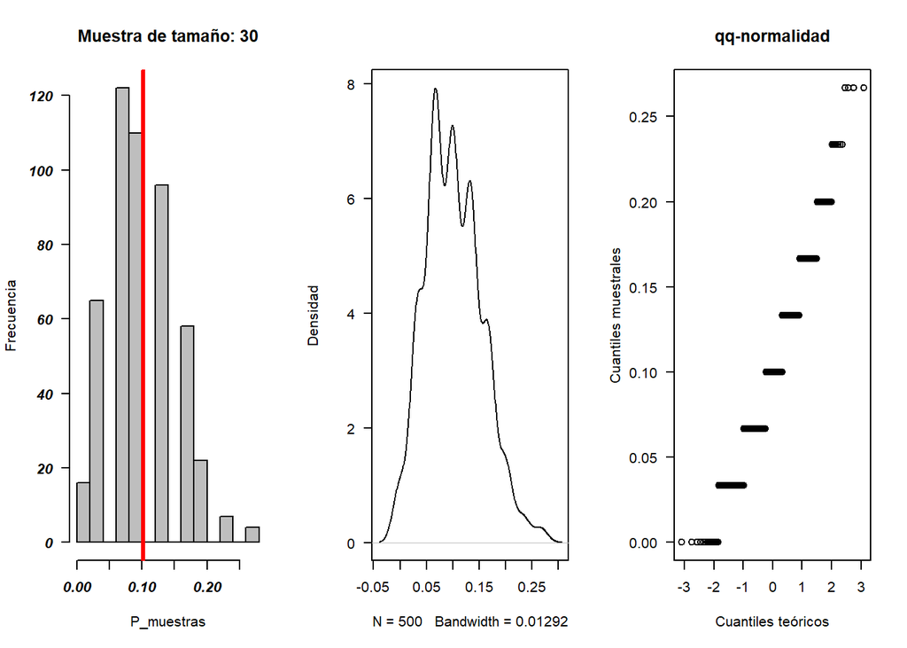

```
## [1] "Para una muestra de tamaño:  30"
##
##  Shapiro-Wilk normality test
##
## data:  P_muestras
## W = 0.95217, p-value = 1.208e-11
```

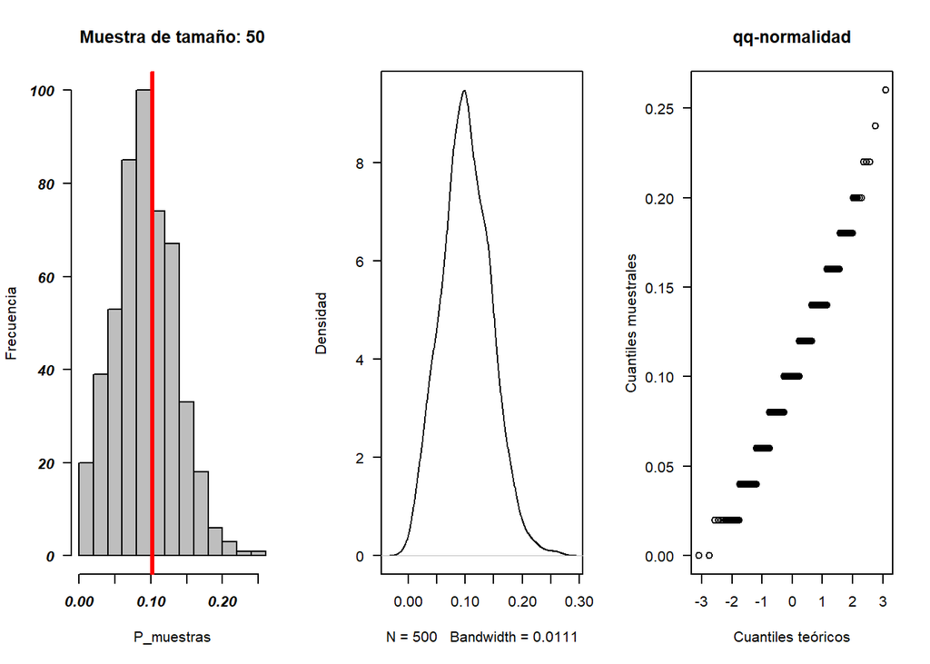

```
## [1] "Para una muestra de tamaño:  50"
##
##  Shapiro-Wilk normality test
##
## data:  P_muestras
## W = 0.9759, p-value = 2.439e-07
```

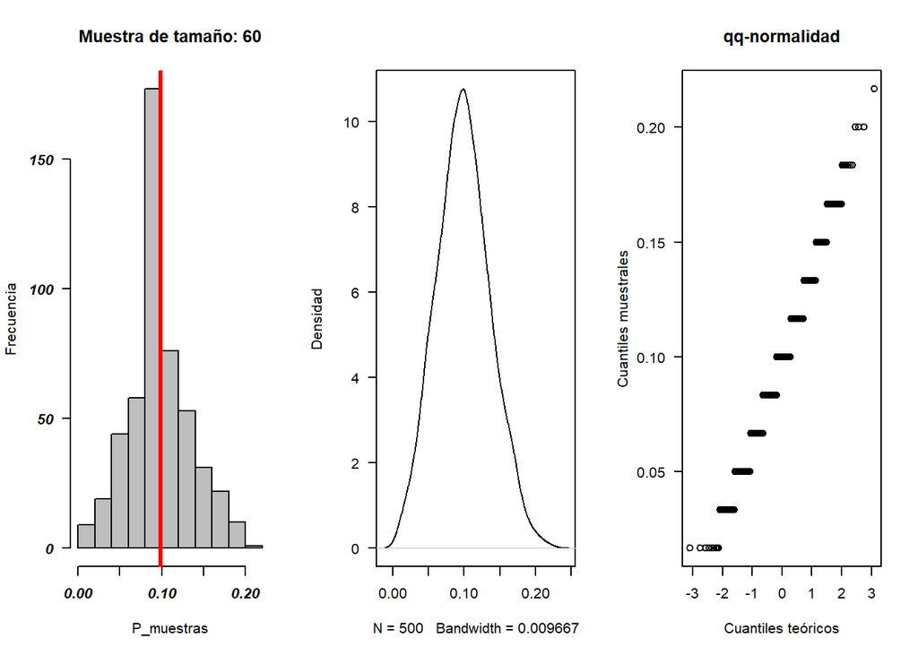

```
## [1] "Para una muestra de tamaño:  60"
##
##  Shapiro-Wilk normality test
##
## data:  P_muestras
## W = 0.97913, p-value = 1.404e-06
```

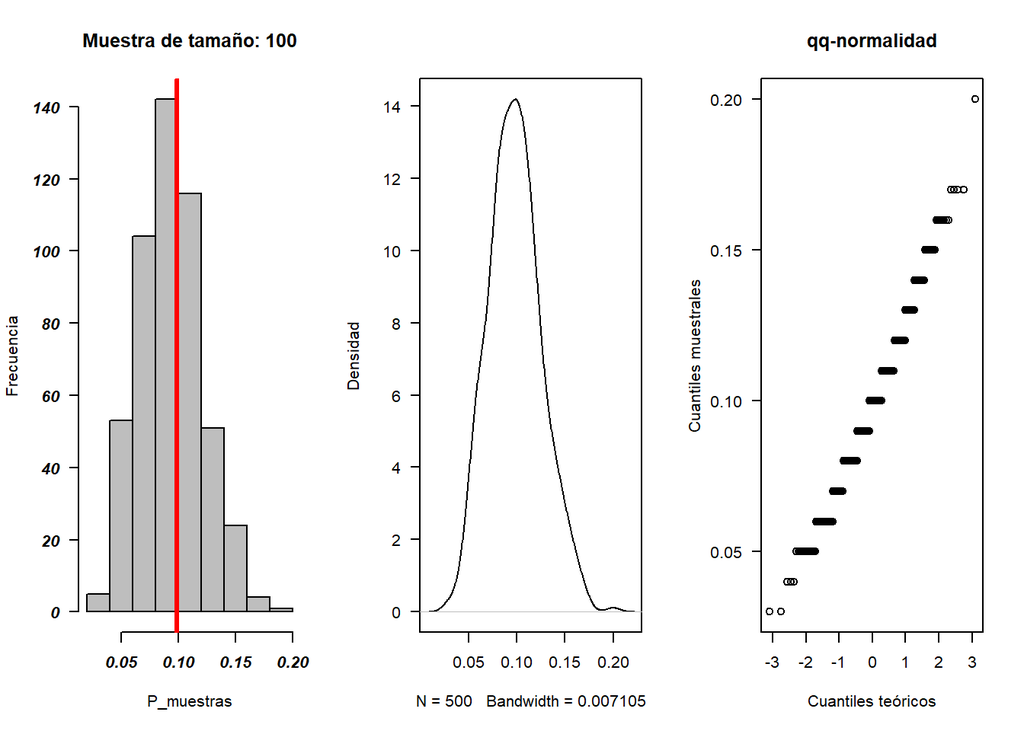

```
## [1] "Para una muestra de tamaño:  100"
##
##  Shapiro-Wilk normality test
##
## data:  P_muestras
## W = 0.98199, p-value = 7.439e-06
```

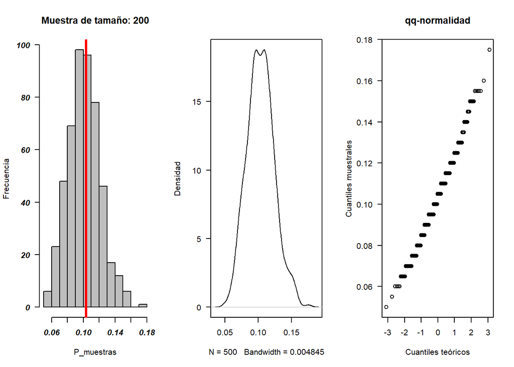

```
## [1] "Para una muestra de tamaño:  200"
##
##  Shapiro-Wilk normality test
##
## data:  P_muestras
## W = 0.98968, p-value = 0.001389
```

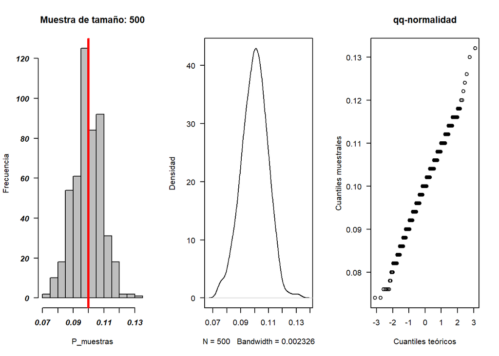

```
## [1] "Para una muestra de tamaño:  500"
##
##  Shapiro-Wilk normality test
##
## data:  P_muestras
## W = 0.99278, p-value = 0.0165
```

```r
t_Muestras = c(10,15,20,30,50,60,100,200,500)
iter = 500

for (i in 1:length(t_Muestras)) {
  P_muestras = GenerarMuestra_Iter (Pob = Lote2, Tam = t_Muestras[i], Con = "Enfermo",Iter = iter)
  par(mfrow=c(1,3))
  hist(P_muestras, las=1, ylab = "Frecuencia",
       main = paste("Muestra de tamaño:", t_Muestras[i]), col = "gray", las=1,
       font.axis=4)
  abline(v=mean(P_muestras), col="red", lwd=3)
  plot(density(P_muestras), las=1, ylab = "Densidad", main = "")
  qqnorm(P_muestras, xlab="Cuantiles teóricos", ylab="Cuantiles muestrales",las=1,main="qq-normalidad")
  print(paste('Para una muestra de tamaño: ', t_Muestras[i]))
  print(shapiro.test(P_muestras))

}
```

```r
Lote3 = GenerarPoblacion(Tot = 1000, Enf = 0.9, San = 0.1)
```

```
## [1] "Lote Generado de tamaño:  1000  Enfermos:  900 Sanos:  100"
```

```r
n3 = 300
muestra = GenerarMuestra (Pob = Lote3, Tam = n3, Con = "Enfermo")

print(paste("Para una muestra de tamaño:", n3, "un estimador de la proporción =", muestra))
```

```
## [1] "Para una muestra de tamaño: 300 un estimador de la proporción = 0.9"
```

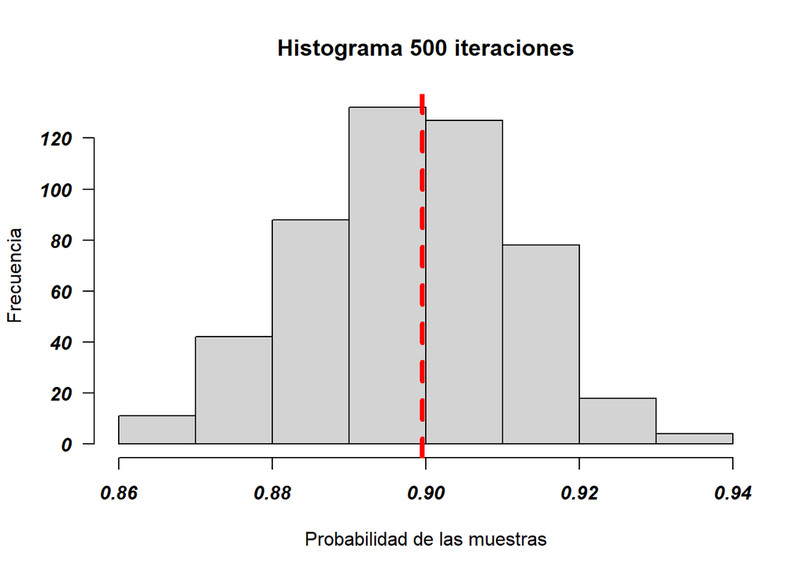

```r
GenerarMuestra_Iter = function(Pob, Tam, Con, Iter) {
  if (Tam <= length(Pob)) {
    muestra_iter = array(NA,Iter)
    for (i in 1:Iter) {
      muestra_iter[i] = GenerarMuestra (Pob, Tam, Con)
    }
    return(muestra_iter)
  }
  else {
    print("Error: el tamaño de la muestra supera el tamaño de la población.")
    return(-1)
  }
}


iter = 500
P_muestras = GenerarMuestra_Iter(Pob = Lote3, Tam = n3, Con = "Enfermo",Iter = iter)

hist(P_muestras, main = "Histograma 500 iteraciones",
     xlab = "Probabilidad de las muestras", ylab = "Frecuencia", las = 1,
     font.axis = 4)
line = mean(P_muestras)

abline (v=line, lwd = 4, lty = 2, col="red")
```

```r
skim(P_muestras)
```

Data summary

| Name | P_muestras |
| --- | --- |
| Number of rows | 500 |
| Number of columns | 1 |
| _______________________ |  |
| Column type frequency: |  |
| numeric | 1 |
| ________________________ |  |
| Group variables | None |

**Variable type: numeric**

| skim_variable | n_missing | complete_rate | mean | sd | p0 | p25 | p50 | p75 | p100 | hist |
| --- | --- | --- | --- | --- | --- | --- | --- | --- | --- | --- |
| data | 0 | 1 | 0.9 | 0.01 | 0.86 | 0.89 | 0.9 | 0.91 | 0.94 | ▁▅▇▅▁ |

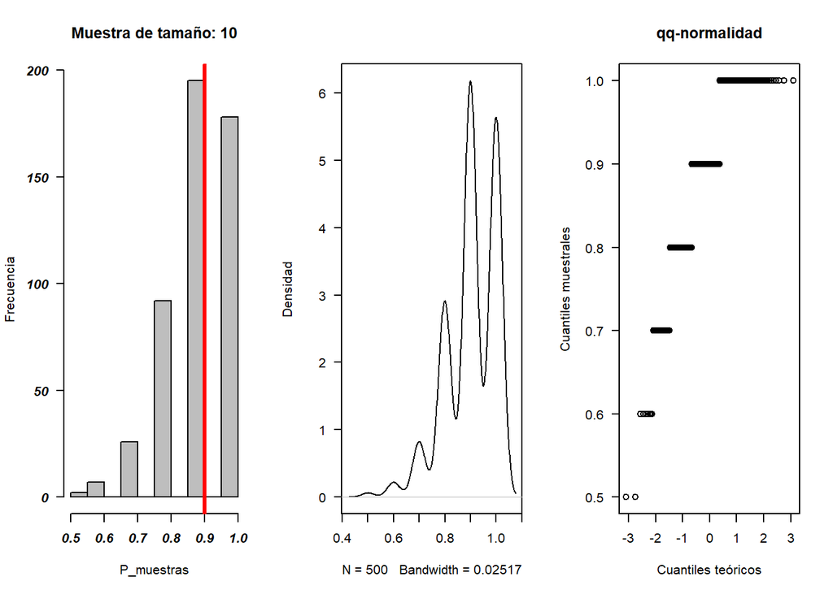

```
## [1] "Para una muestra de tamaño:  10"
##
##  Shapiro-Wilk normality test
##
## data:  P_muestras
## W = 0.83244, p-value < 2.2e-16
```

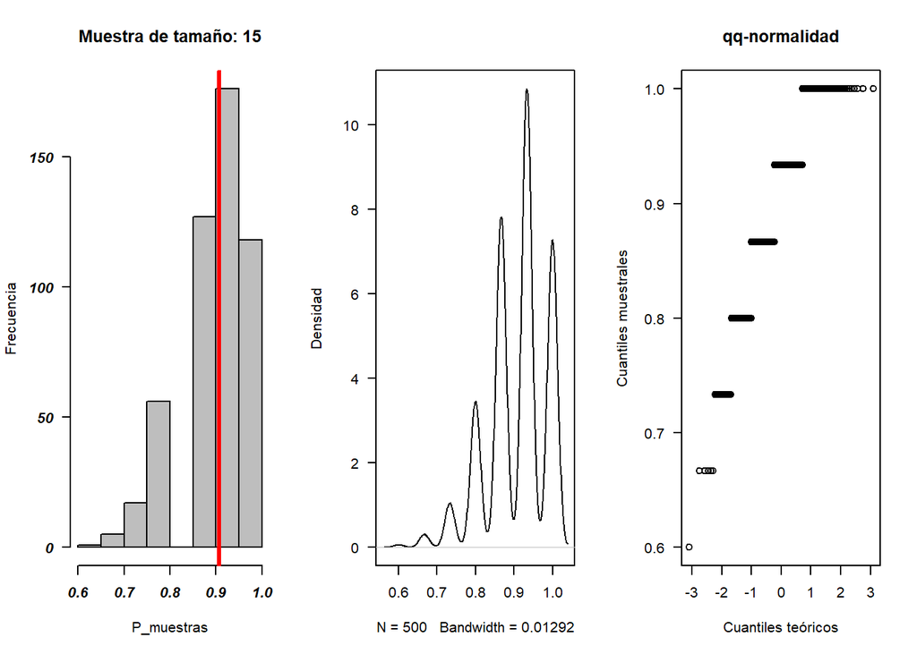

```
## [1] "Para una muestra de tamaño:  15"
##
##  Shapiro-Wilk normality test
##
## data:  P_muestras
## W = 0.88595, p-value < 2.2e-16
```

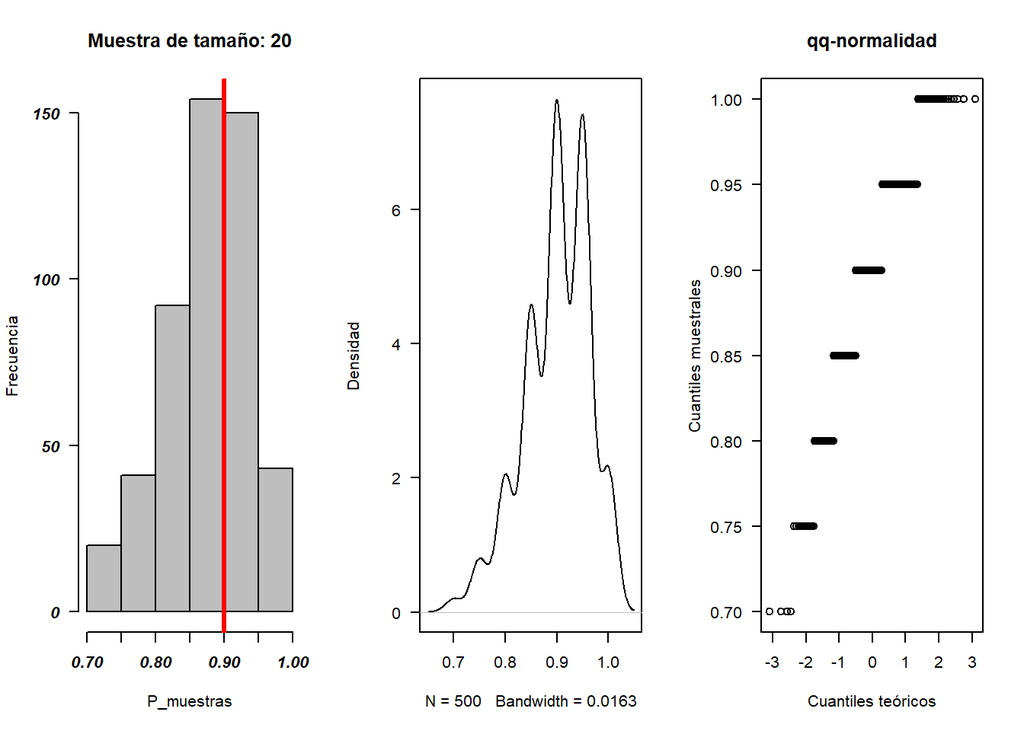

```
## [1] "Para una muestra de tamaño:  20"
##
##  Shapiro-Wilk normality test
##
## data:  P_muestras
## W = 0.91715, p-value = 6.274e-16
```

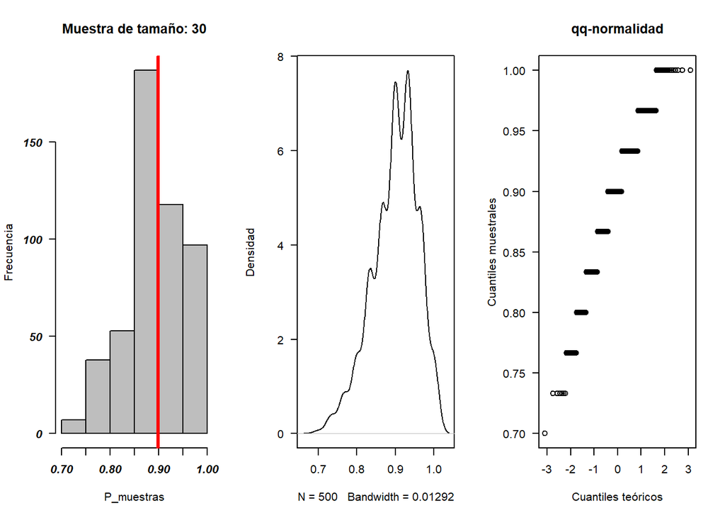

```
## [1] "Para una muestra de tamaño:  30"
##
##  Shapiro-Wilk normality test
##
## data:  P_muestras
## W = 0.94711, p-value = 2.259e-12
```

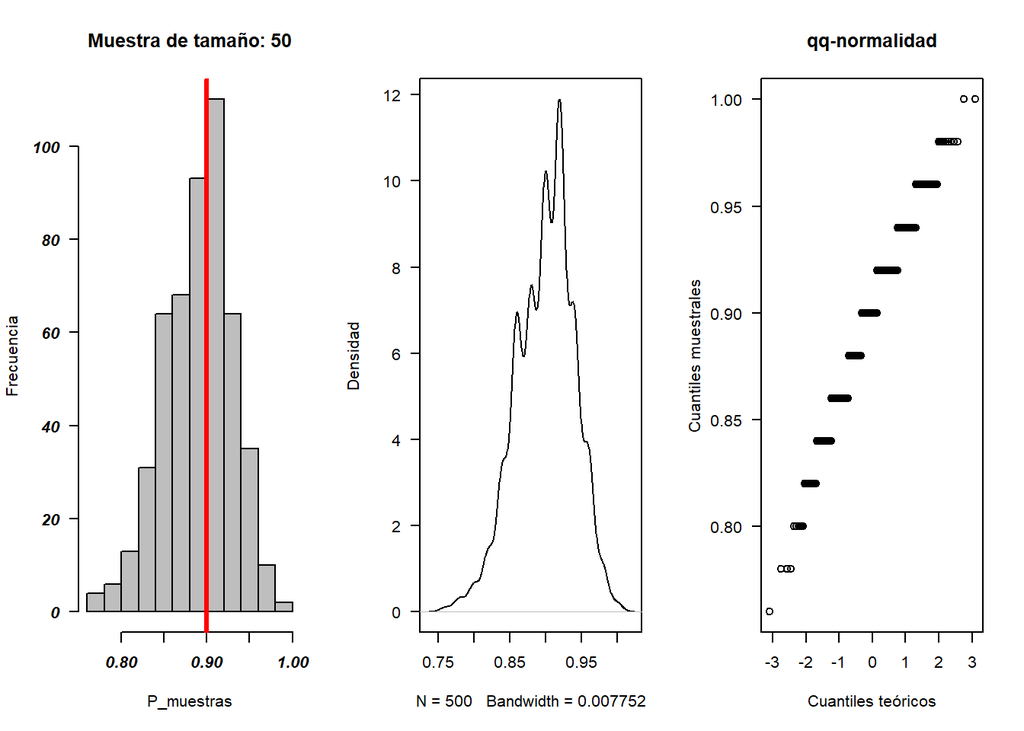

```
## [1] "Para una muestra de tamaño:  50"
##
##  Shapiro-Wilk normality test
##
## data:  P_muestras
## W = 0.96941, p-value = 1.049e-08
```

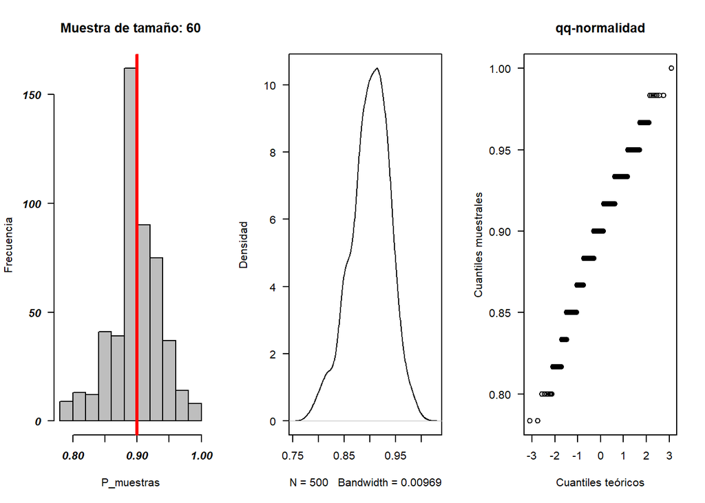

```
## [1] "Para una muestra de tamaño:  60"
##
##  Shapiro-Wilk normality test
##
## data:  P_muestras
## W = 0.97162, p-value = 2.924e-08
```

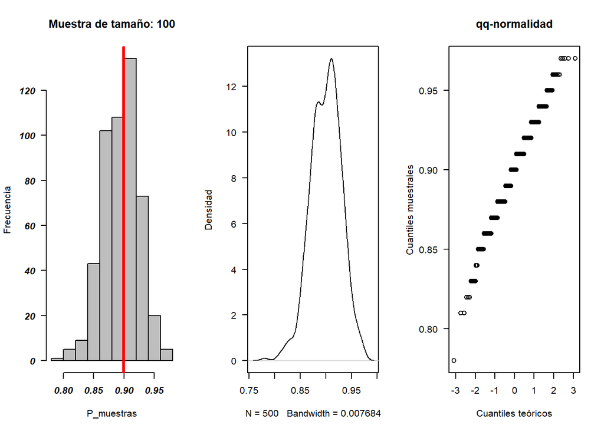

```
## [1] "Para una muestra de tamaño:  100"
##
##  Shapiro-Wilk normality test
##
## data:  P_muestras
## W = 0.983, p-value = 1.386e-05
```

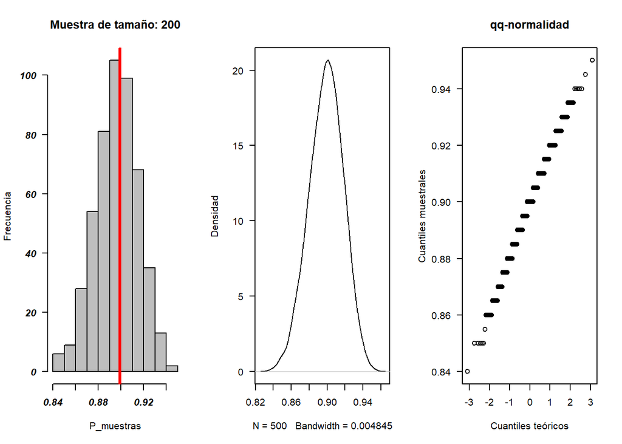

```
## [1] "Para una muestra de tamaño:  200"
##
##  Shapiro-Wilk normality test
##
## data:  P_muestras
## W = 0.99095, p-value = 0.003709
```

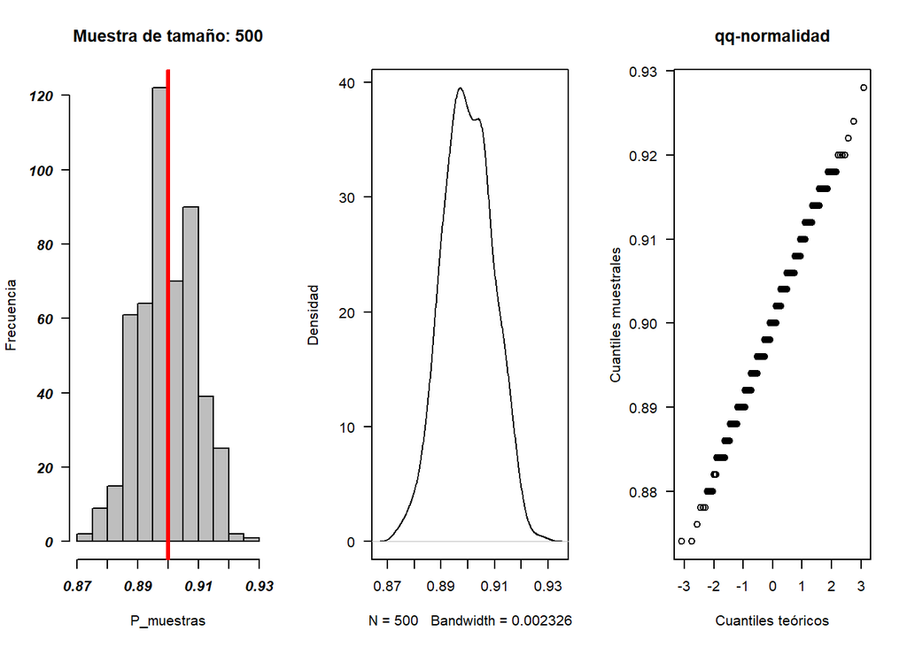

```
## [1] "Para una muestra de tamaño:  500"
##
##  Shapiro-Wilk normality test
##
## data:  P_muestras
## W = 0.99379, p-value = 0.03839
```

```r
t_Muestras = c(10,15,20,30,50,60,100,200,500)
iter = 500

for (i in 1:length(t_Muestras)) {
  P_muestras = GenerarMuestra_Iter (Pob = Lote3, Tam = t_Muestras[i], Con = "Enfermo",Iter = iter)
  par(mfrow=c(1,3))
  hist(P_muestras, las=1, ylab = "Frecuencia",
       main = paste("Muestra de tamaño:", t_Muestras[i]), col = "gray", las=1,
       font.axis=4)
  abline(v=mean(P_muestras), col="red", lwd=3)
  plot(density(P_muestras), las=1, ylab = "Densidad", main = "")
  qqnorm(P_muestras, xlab="Cuantiles teóricos", ylab="Cuantiles muestrales",las=1,main="qq-normalidad")
  print(paste('Para una muestra de tamaño: ', t_Muestras[i]))
  print(shapiro.test(P_muestras))

}
```

## **Conclusiones**

Por medio del teorema del límite central podemos observar que a medida que aumenta el tamaño de la muestra, es valor de P estimado, se acerca más al valor de *P*, disminuye la varianza, y converge hacia una distribución normal. Con respecto a la gráfica qq-normalidad a medida que aumenta el tamaño de la muestra, los puntos se van ajustando a la diagonal.